# Oviposition Logisitic

Ryan Peek

Updated: 2017-03-21

## Try Model, Model Fail

Let’s try to assess whether water temperature, air temperature, flow (daily/weekly recession rates & discharge) play a role in predicting when breeding (oviposition occurs). To build this model we need to block by river, and by water year, as these are independent (though water year isn’t *fixed*, it is fixed across all sites per each year).

First let’s take a look at some test data. Using a subset (say just pull the **NF American**), can we build a model that gets at whether there is predictability in these variables despite shifts in timing and magnitude from year to year?

#### Get the Data

```r
library(tidyverse)
library(lubridate)
sites <- c("NFA", "NFY")

frogBreed <- read_csv("data/oviposition_start_mainstem_sites.csv") %>%
  mutate(estim_strt=mdy(estim_strt),
         obs_strt=mdy(obs_strt)) %>%
  filter(Site %in% sites)
hydroDat <- read_csv("data/oviposition_glm_stgtemps_long.csv") %>%
  mutate(Date=mdy(Date))
```

#### Tidy and Merge the Data

```r
source('scripts/functions/f_doy.R') # for adding year date cols

# join the data together:
data1 <- left_join(hydroDat, frogBreed, by = c("Date"="estim_strt")) %>%
  mutate(site=as.factor(toupper(site)),
         Site = as.factor(Site)) %>%
  add_WYD(., "Date")

# select only data for a test (May-Jun for NFY/NFA)

nfdf <- data1 %>% filter(site %in% sites) %>%
  filter(DOY>120, DOY<182) %>%
  select(Date, site, Site, WYT, DOY:DOWY, air.7:level.7dL, -ppt2_in, -days_wo_ppt2) %>% rename(breedSite=Site)

summary(nfdf)
```

```
##       Date             site     breedSite      WYT
##  Min.   :2011-05-01   MFA:  0   NFA :  6   Length:366
##  1st Qu.:2011-06-15   NFA:183   NFY :  4   Class :character
##  Median :2012-05-30   NFY:183   NA's:356   Mode  :character
##  Mean   :2012-05-30   RUB:  0
##  3rd Qu.:2013-05-15   SFY:  0
##  Max.   :2013-06-30   YUB:  0
##
##     DOY.V1         WY.V1         DOWY.V1        air.7
##  Min.   :121   Min.   :2011   Min.   :213   Min.   : 7.001
##  1st Qu.:136   1st Qu.:2011   1st Qu.:228   1st Qu.:13.015
##  Median :151   Median :2012   Median :243   Median :15.476
##  Mean   :151   Mean   :2012   Mean   :243   Mean   :15.709
##  3rd Qu.:166   3rd Qu.:2013   3rd Qu.:258   3rd Qu.:18.400
##  Max.   :181   Max.   :2013   Max.   :273   Max.   :26.702
##                                             NA's   :48
##      baro.7         airmin.7         airmax.7         ppt_in
##  Min.   :27.45   Min.   : 1.143   Min.   :12.14   Min.   :0.00000
##  1st Qu.:27.55   1st Qu.: 5.893   1st Qu.:20.00   1st Qu.:0.00000
##  Median :28.60   Median : 7.714   Median :23.50   Median :0.00000
##  Mean   :28.15   Mean   : 8.181   Mean   :23.19   Mean   :0.05598
##  3rd Qu.:28.72   3rd Qu.:10.143   3rd Qu.:26.14   3rd Qu.:0.00000
##  Max.   :28.92   Max.   :18.000   Max.   :35.14   Max.   :2.26000
##  NA's   :48      NA's   :48       NA's   :48
##   days_wo_ppt       level.avg         temp.avg        level.max
##  Min.   : 0.000   Min.   :0.5837   Min.   : 4.909   Min.   :0.597
##  1st Qu.: 1.000   1st Qu.:1.0343   1st Qu.: 9.104   1st Qu.:1.066
##  Median : 5.000   Median :1.3598   Median :12.291   Median :1.415
##  Mean   : 7.781   Mean   :1.4910   Mean   :12.791   Mean   :1.574
##  3rd Qu.:11.000   3rd Qu.:1.8897   3rd Qu.:15.880   3rd Qu.:2.010
##  Max.   :38.000   Max.   :2.8159   Max.   :23.496   Max.   :3.070
##                   NA's   :1        NA's   :1        NA's   :1
##     temp.max       level.min         temp.min       level.avg.7
##  Min.   : 5.75   Min.   :0.5675   Min.   : 4.285   Min.   :0.629
##  1st Qu.:10.46   1st Qu.:1.0142   1st Qu.: 7.800   1st Qu.:1.031
##  Median :13.38   Median :1.3197   Median :11.165   Median :1.349
##  Mean   :14.02   Mean   :1.4256   Mean   :11.612   Mean   :1.491
##  3rd Qu.:17.16   3rd Qu.:1.8053   3rd Qu.:14.934   3rd Qu.:1.908
##  Max.   :25.00   Max.   :2.5435   Max.   :22.636   Max.   :2.634
##  NA's   :1       NA's   :1        NA's   :1
##    temp.avg.7      level.max.7       temp.max.7      level.min.7
##  Min.   : 6.249   Min.   :0.6496   Min.   : 7.626   Min.   :0.6056
##  1st Qu.: 8.889   1st Qu.:1.0685   1st Qu.:10.340   1st Qu.:1.0151
##  Median :12.609   Median :1.4065   Median :13.419   Median :1.3105
##  Mean   :12.810   Mean   :1.5739   Mean   :14.037   Mean   :1.4248
##  3rd Qu.:15.979   3rd Qu.:2.0003   3rd Qu.:17.163   3rd Qu.:1.8140
##  Max.   :22.363   Max.   :2.9254   Max.   :23.541   Max.   :2.4341
##
##    temp.min.7       level.7dL
##  Min.   : 5.058   Min.   :-7.00112
##  1st Qu.: 7.789   1st Qu.:-1.86735
##  Median :11.382   Median :-0.89828
##  Mean   :11.631   Mean   :-0.57632
##  3rd Qu.:14.822   3rd Qu.: 0.05882
##  Max.   :21.127   Max.   : 7.77873
##
```

```r
# remove NAs and non-NF sites:
nfdf <- nfdf %>% filter(!is.na(air.7), !is.na(level.avg))
summary(nfdf)
```

```
##       Date             site     breedSite      WYT
##  Min.   :2011-05-01   MFA:  0   NFA :  5   Length:317
##  1st Qu.:2011-06-20   NFA:163   NFY :  3   Class :character
##  Median :2012-06-01   NFY:154   NA's:309   Mode  :character
##  Mean   :2012-06-09   RUB:  0
##  3rd Qu.:2013-05-22   SFY:  0
##  Max.   :2013-06-30   YUB:  0
##        DOY.V1               WY.V1              DOWY.V1
##  Min.   :121.00000   Min.   :2011.0000   Min.   :213.00000
##  1st Qu.:136.00000   1st Qu.:2011.0000   1st Qu.:228.00000
##  Median :150.00000   Median :2012.0000   Median :242.00000
##  Mean   :151.10095   Mean   :2012.0284   Mean   :243.10095
##  3rd Qu.:166.00000   3rd Qu.:2013.0000   3rd Qu.:258.00000
##  Max.   :181.00000   Max.   :2013.0000   Max.   :273.00000
##      air.7            baro.7         airmin.7         airmax.7
##  Min.   : 7.001   Min.   :27.45   Min.   : 1.143   Min.   :12.14
##  1st Qu.:12.999   1st Qu.:27.55   1st Qu.: 5.857   1st Qu.:20.00
##  Median :15.482   Median :28.60   Median : 7.714   Median :23.57
##  Mean   :15.711   Mean   :28.15   Mean   : 8.183   Mean   :23.19
##  3rd Qu.:18.409   3rd Qu.:28.72   3rd Qu.:10.143   3rd Qu.:26.14
##  Max.   :26.702   Max.   :28.92   Max.   :18.000   Max.   :35.14
##      ppt_in         days_wo_ppt       level.avg         temp.avg
##  Min.   :0.00000   Min.   : 0.000   Min.   :0.5837   Min.   : 4.909
##  1st Qu.:0.00000   1st Qu.: 1.000   1st Qu.:0.9847   1st Qu.: 9.536
##  Median :0.00000   Median : 5.000   Median :1.3301   Median :12.428
##  Mean   :0.04562   Mean   : 8.142   Mean   :1.4738   Mean   :13.142
##  3rd Qu.:0.00000   3rd Qu.:12.000   3rd Qu.:1.8636   3rd Qu.:16.594
##  Max.   :1.32000   Max.   :38.000   Max.   :2.8159   Max.   :23.496
##    level.max        temp.max       level.min         temp.min
##  Min.   :0.597   Min.   : 5.75   Min.   :0.5675   Min.   : 4.285
##  1st Qu.:1.019   1st Qu.:10.49   1st Qu.:0.9424   1st Qu.: 8.570
##  Median :1.381   Median :13.91   Median :1.2845   Median :11.387
##  Mean   :1.554   Mean   :14.32   Mean   :1.4117   Mean   :11.992
##  3rd Qu.:1.968   3rd Qu.:18.04   3rd Qu.:1.7848   3rd Qu.:15.283
##  Max.   :3.070   Max.   :25.00   Max.   :2.5435   Max.   :22.636
##   level.avg.7       temp.avg.7      level.max.7       temp.max.7
##  Min.   :0.6290   Min.   : 6.249   Min.   :0.6496   Min.   : 7.626
##  1st Qu.:0.9747   1st Qu.: 9.413   1st Qu.:1.0150   1st Qu.:10.324
##  Median :1.3368   Median :12.796   Median :1.3881   Median :13.558
##  Mean   :1.4745   Mean   :13.153   Mean   :1.5546   Mean   :14.333
##  3rd Qu.:1.8680   3rd Qu.:16.624   3rd Qu.:1.9661   3rd Qu.:18.274
##  Max.   :2.6343   Max.   :22.363   Max.   :2.9254   Max.   :23.541
##   level.min.7       temp.min.7       level.7dL
##  Min.   :0.6056   Min.   : 5.058   Min.   :-7.00112
##  1st Qu.:0.9352   1st Qu.: 8.209   1st Qu.:-1.88480
##  Median :1.2963   Median :11.672   Median :-0.92259
##  Mean   :1.4115   Mean   :12.000   Mean   :-0.72490
##  3rd Qu.:1.7802   3rd Qu.:15.282   3rd Qu.:-0.07805
##  Max.   :2.4341   Max.   :21.127   Max.   : 7.70560
```

```r
# add binary 1 or 0 for breeding
nfdf <- nfdf %>% mutate(ovipos=ifelse(is.na(breedSite), 0, 1))
```

## Logistic `glm` Model

Now let’s run a model. See [here](http://stats.idre.ucla.edu/r/dae/logit-regression/)

```r
# get data
d <- nfdf %>% select(ovipos, site, WY, DOY, airmin.7, days_wo_ppt, level.avg, temp.min.7, level.7dL)
# two-way contingency table of categ outcome and predictors, no zeros?

# fix index
d$river_id <- as.integer(as.factor(d$site))
d$WY_id <- as.integer(as.factor(d$WY))

xtabs(~ovipos + DOY, data = d)
```

```
##       DOY
## ovipos 121 122 123 124 125 126 127 128 129 130 131 132 133 134 135 136 137
##      0   5   5   5   5   5   5   5   5   5   4   5   5   4   5   5   5   5
##      1   0   0   0   0   0   0   0   0   0   1   0   0   1   0   0   0   0
##       DOY
## ovipos 138 139 140 141 142 143 144 145 146 147 148 149 150 151 152 153 154
##      0   5   3   6   3   6   6   6   6   6   6   6   6   5   5   5   5   5
##      1   0   2   0   2   0   0   0   0   0   0   0   0   0   0   0   0   0
##       DOY
## ovipos 155 156 157 158 159 160 161 162 163 164 165 166 167 168 169 170 171
##      0   5   5   5   5   5   5   5   5   5   5   5   5   5   5   5   5   5
##      1   0   0   0   0   0   0   0   0   0   0   0   0   0   0   0   0   0
##       DOY
## ovipos 172 173 174 175 176 177 178 179 180 181
##      0   5   5   5   5   5   5   5   6   6   4
##      1   0   0   0   0   0   0   0   0   0   2
```

```r
xtabs(~ovipos + days_wo_ppt, data = d)
```

```
##       days_wo_ppt
## ovipos  0  1  2  3  4  5  6  7  8  9 10 11 12 13 14 15 16 17 18 19 20 21
##      0 57 26 21 20 21 17 13 13 10 11 10  9  8  8  5  5  5  5  4  4  4  4
##      1  1  1  1  0  0  0  1  0  1  0  0  0  0  0  0  0  0  0  0  0  0  0
##       days_wo_ppt
## ovipos 22 23 24 25 26 27 28 29 30 31 32 33 34 35 36 37 38
##      0  3  3  2  2  2  2  2  2  2  2  1  1  1  1  1  1  1
##      1  1  0  1  0  0  0  0  0  0  0  1  0  0  0  0  0  0
```

```r
# factor the data that is factorable
str(d)
```

```
## Classes 'tbl_df', 'tbl' and 'data.frame':    317 obs. of  11 variables:
##  $ ovipos     : num  0 0 0 0 0 0 0 0 0 0 ...
##  $ site       : Factor w/ 6 levels "MFA","NFA","NFY",..: 2 2 2 2 2 2 2 2 2 2 ...
##  $ WY         : num [1:317, 1] 2011 2011 2011 2011 2011 ...
##  $ DOY        : num [1:317, 1] 121 122 123 124 125 126 127 128 129 130 ...
##  $ airmin.7   : num  4.86 5.29 6 6.71 7.29 ...
##  $ days_wo_ppt: int  6 7 8 9 10 11 12 13 0 1 ...
##  $ level.avg  : num  2.28 2.26 2.34 2.45 2.52 ...
##  $ temp.min.7 : num  7.07 7.13 7.14 7.17 7.31 ...
##  $ level.7dL  : num  0.0706 0.8542 1.34 1.9095 2.6766 ...
##  $ river_id   : int  2 2 2 2 2 2 2 2 2 2 ...
##  $ WY_id      : int  1 1 1 1 1 1 1 1 1 1 ...
```

```r
d$site <- factor(d$site)
d$WY <- factor(d$WY)

# run a logistic binomial response model
mylogit <- glm(ovipos ~ river_id + WY_id + DOY + airmin.7 + days_wo_ppt +
                 level.avg + temp.min.7 + level.7dL, data = d, family = "binomial")
summary(mylogit)
```

```
##
## Call:
## glm(formula = ovipos ~ river_id + WY_id + DOY + airmin.7 + days_wo_ppt +
##     level.avg + temp.min.7 + level.7dL, family = "binomial",
##     data = d)
##
## Deviance Residuals:
##      Min        1Q    Median        3Q       Max
## -0.73950  -0.22121  -0.08946  -0.03799   2.80851
##
## Coefficients:
##              Estimate Std. Error z value Pr(>|z|)
## (Intercept) -22.40010   10.26884  -2.181   0.0292 *
## river_id      5.67902    2.34973   2.417   0.0157 *
## WY_id        -0.77397    1.54456  -0.501   0.6163
## DOY          -0.06878    0.05017  -1.371   0.1703
## airmin.7      0.87931    0.44025   1.997   0.0458 *
## days_wo_ppt   0.06349    0.05368   1.183   0.2369
## level.avg     3.38889    1.96307   1.726   0.0843 .
## temp.min.7    0.17352    0.40710   0.426   0.6699
## level.7dL    -0.16646    0.26331  -0.632   0.5273
## ---
## Signif. codes:  0 '***' 0.001 '**' 0.01 '*' 0.05 '.' 0.1 ' ' 1
##
## (Dispersion parameter for binomial family taken to be 1)
##
##     Null deviance: 74.668  on 316  degrees of freedom
## Residual deviance: 57.295  on 308  degrees of freedom
## AIC: 75.295
##
## Number of Fisher Scoring iterations: 8
```

You can calculate the confidence intervals using the `confint` function.

```r
confint(mylogit)
```

```
##                    2.5 %      97.5 %
## (Intercept) -45.66538098 -4.50785928
## river_id      1.64807263 11.05269619
## WY_id        -3.97039493  2.39338033
## DOY          -0.18023023  0.02269954
## airmin.7      0.13790025  1.88786349
## days_wo_ppt  -0.04511295  0.17181553
## level.avg    -0.15499635  7.74560913
## temp.min.7   -0.63779588  0.98651789
## level.7dL    -0.68784551  0.33868056
```

```r
library(aod)
# Can use a wald.test to test coefficients in order they appear in model
aod::wald.test(b= coef(mylogit), Sigma = vcov(mylogit), Terms=c(1,4))
```

```
## Wald test:
## ----------
##
## Chi-squared test:
## X2 = 6.9, df = 2, P(> X2) = 0.031
```

```r
## odds ratios and 95% CI
exp(cbind(OR = coef(mylogit), confint(mylogit)))
```

```
##                       OR        2.5 %       97.5 %
## (Intercept) 1.869651e-10 1.471557e-20 1.102203e-02
## river_id    2.926636e+02 5.196954e+00 6.311389e+04
## WY_id       4.611797e-01 1.886598e-02 1.095045e+01
## DOY         9.335301e-01 8.350779e-01 1.022959e+00
## airmin.7    2.409235e+00 1.147861e+00 6.605241e+00
## days_wo_ppt 1.065545e+00 9.558895e-01 1.187459e+00
## level.avg   2.963304e+01 8.564183e-01 2.311401e+03
## temp.min.7  1.189480e+00 5.284559e-01 2.681880e+00
## level.7dL   8.466606e-01 5.026579e-01 1.403095e+00
```

```r
# simulate and predict

newdata1 <- d %>% select(ovipos, site, DOY:WY_id) %>% group_by(WY_id, river_id, DOY) %>%
  summarize(airmin.7 = mean(airmin.7),
            days_wo_ppt = mean(days_wo_ppt),
            level.avg = mean(level.avg),
            temp.min.7 = mean(temp.min.7),
            level.7dL = mean(level.7dL))

# predict
newdata1$rankP <- predict(mylogit, newdata = newdata1, type = "response")
newdata1
```

```
## Source: local data frame [317 x 9]
## Groups: WY_id, river_id [?]
##
##    WY_id river_id   DOY airmin.7 days_wo_ppt level.avg temp.min.7
##    <int>    <int> <dbl>    <dbl>       <dbl>     <dbl>      <dbl>
## 1      1        2   121 4.857143           6  2.281938   7.069286
## 2      1        2   122 5.285714           7  2.263021   7.132143
## 3      1        2   123 6.000000           8  2.344896   7.135714
## 4      1        2   124 6.714286           9  2.451229   7.173571
## 5      1        2   125 7.285714          10  2.515146   7.305714
## 6      1        2   126 7.285714          11  2.624938   7.387857
## 7      1        2   127 7.000000          12  2.749625   7.254286
## 8      1        2   128 7.000000          13  2.741083   7.110714
## 9      1        2   129 6.857143           0  2.669771   7.211429
## 10     1        2   130 6.714286           1  2.399708   7.247857
## # ... with 307 more rows, and 2 more variables: level.7dL <dbl>,
## #   rankP <dbl>
```

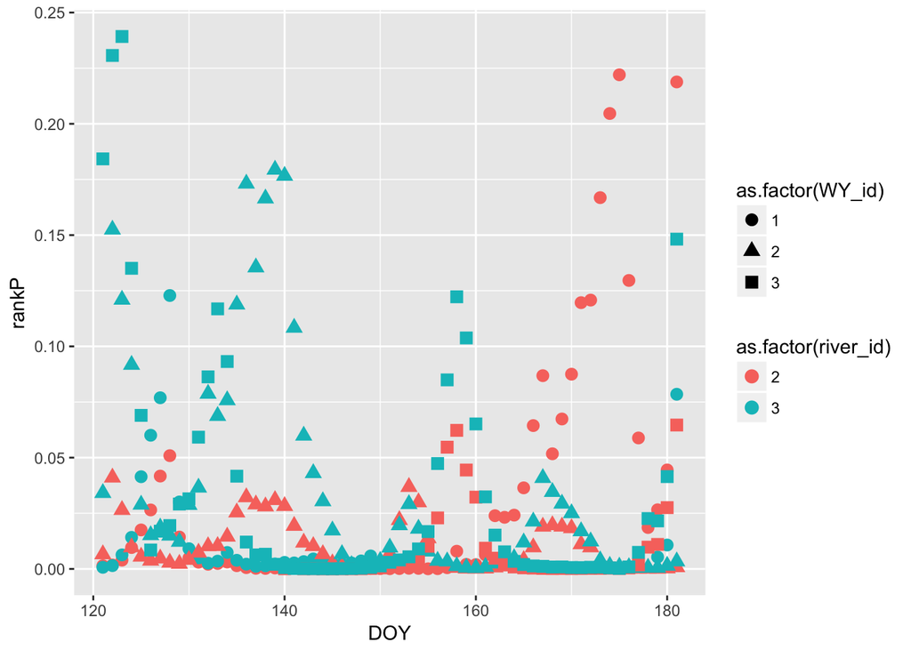

```r
ggplot() + geom_point(data=newdata1, aes(x=DOY, y=rankP, color=as.factor(river_id), shape=as.factor(WY_id)), size=3)
```

## Rethinking Model

```r
library(rethinking)

# get data
d <- nfdf %>% select(ovipos, site, WY, DOY, airmin.7, days_wo_ppt, level.avg, temp.min.7, level.7dL)

# fix index
d$river_id <- as.integer(as.factor(d$site))
d$WY_id <- as.integer(as.factor(d$WY))

# rename outcome so it doesn't have a dot in it
dlist <- list(
    river = d$river_id,
    DOY = d$DOY,
    WY = d$WY_id,
    airmin7 = d$airmin.7,
    days_wo_ppt = d$days_wo_ppt,
    level = d$level.avg,
    tempmin7 = d$temp.min.7,
    lev7delt = d$level.7dL,
    ovipos = d$ovipos
)

m2.stan <- map2stan(
    alist(
        y ~ dbinom( n , p ),
        logit(p) <- a + bP*pirateL + bV*victimL +
            bA*pirateA + bPA*pirateL*pirateA ,
        a ~ dnorm(0,10),
        bP ~ dnorm(0,5),
        bV ~ dnorm(0,5),
        bA ~ dnorm(0,5),
        bPA ~ dnorm(0,5)
    ) , data=d , warmup=1000 , iter=1e4 )

m1a2 <- map2stan(
    alist(
        ovipos ~ dbinom( DOY , p ),
        logit(p) <- a + a_river[river],
        a ~ dnorm(0,10),
        a_river[river] ~ dnorm(0,sigma),
        sigma ~ dcauchy(0,1)
    ),
    data=dlist)

pred.dat <- list(district=1:60)
pred2 <- link(m1a2,data=pred.dat)

p2.mean <- apply( pred2 , 2 , mean )
round(p2.mean,2)

plot( 1:60 , p1.mean , col=rangi2 , pch=16 , xlab="District" ,
    ylab="probability use contraception" )
points( 1:60 , p2.mean )
abline( h=logistic(coef(m1a2)[1]) , lty=2 ) # plot line for 'a'
```